# 36-315 Lab 07

Due Friday, October 14, 2016 (9:30pm)

Style Guide: http://adv-r.had.co.nz/Style.html

# Problem 1

```r
library(data.table)

olive <- fread("https://raw.githubusercontent.com/sventura/315-code-and-datasets/master/data/olive_oil.csv")
```

# Problem 2

```r
library(dplyr)
olive_sub <- dplyr::select(olive, palmitic, stearic, linoleic, area, region)
```

```r
olive_sub$area <- as.factor(olive_sub$area)
olive_sub$region <- as.factor(olive_sub$region)
```

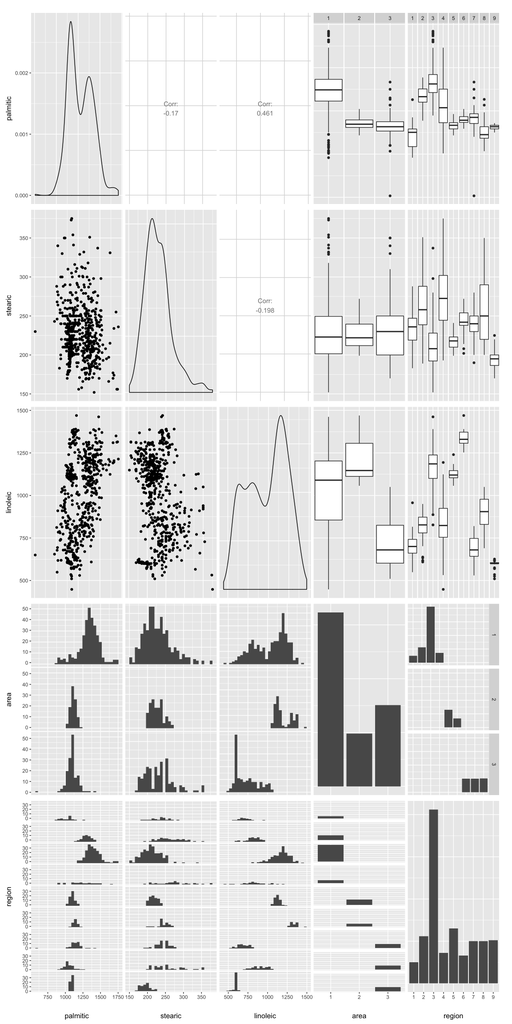

```r
library(GGally)
ggpairs(olive_sub)
```

There is a moderately strong positive correlation between `linoleic` and `palmitic`. Further, it’s interesting that the medians of `stearic` when conditioned on `area` are roughly similar, but when conditioned on `region` they become much more spread out and random (even between regions in the same area).

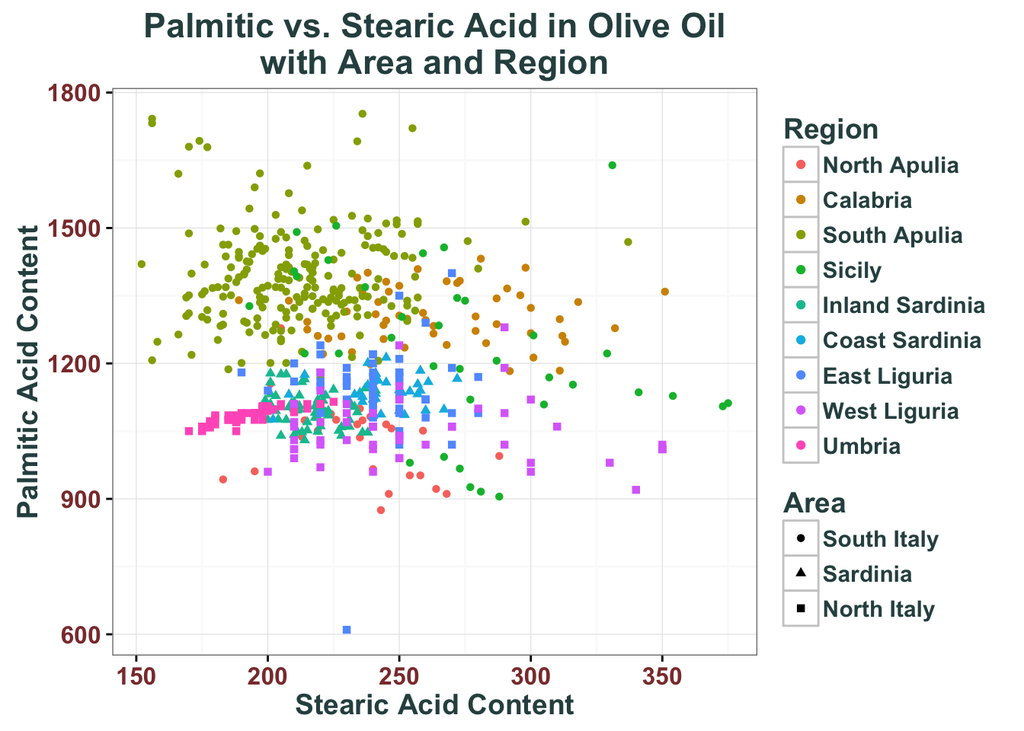

```r
#Mapping from https://www.researchgate.net/publication/239459050_Classification_of_olive_oils_from_their_fatty_acid_composition
library(ggplot2)
my_theme <-  theme_bw() + # White background, black and white theme
  theme(axis.text = element_text(size = 12, color="indianred4"),
        text = element_text(size = 14, face="bold", color="darkslategrey"))

levels(olive_sub$area) <- c("South Italy", "Sardinia", "North Italy")
levels(olive_sub$region) <- c("North Apulia", "Calabria", "South Apulia", "Sicily", "Inland Sardinia", "Coast Sardinia", "East Liguria", "West Liguria", "Umbria")

ggplot2::ggplot(data = olive_sub, aes(x = stearic, y = palmitic)) +
  geom_point(aes(col = region, shape = area)) +
  ggtitle("Palmitic vs. Stearic Acid in Olive Oil\nwith Area and Region") +
  labs(x = "Stearic Acid Content", y = "Palmitic Acid Content",
  col = "Region", shape = "Area") +
  my_theme
```

5. There seems to be a cluster of points from region 3 in the upper left corner (high palmitic acid content and low stearic acid content). There also seems to be a cluster of points from region 9 in the bottom left of the graph (low stearic acid and palmitic acid content). Lastly, the olive oils from area 2 and 3 have low palmitic acid content (they tend to be in the bottom half of the graph), and oils from area 1 have high palmitic acid content (they tend to be in the upper half of the graph). There doesn’t seem to be a relationship between area and stearic content, however.

# Problem 3

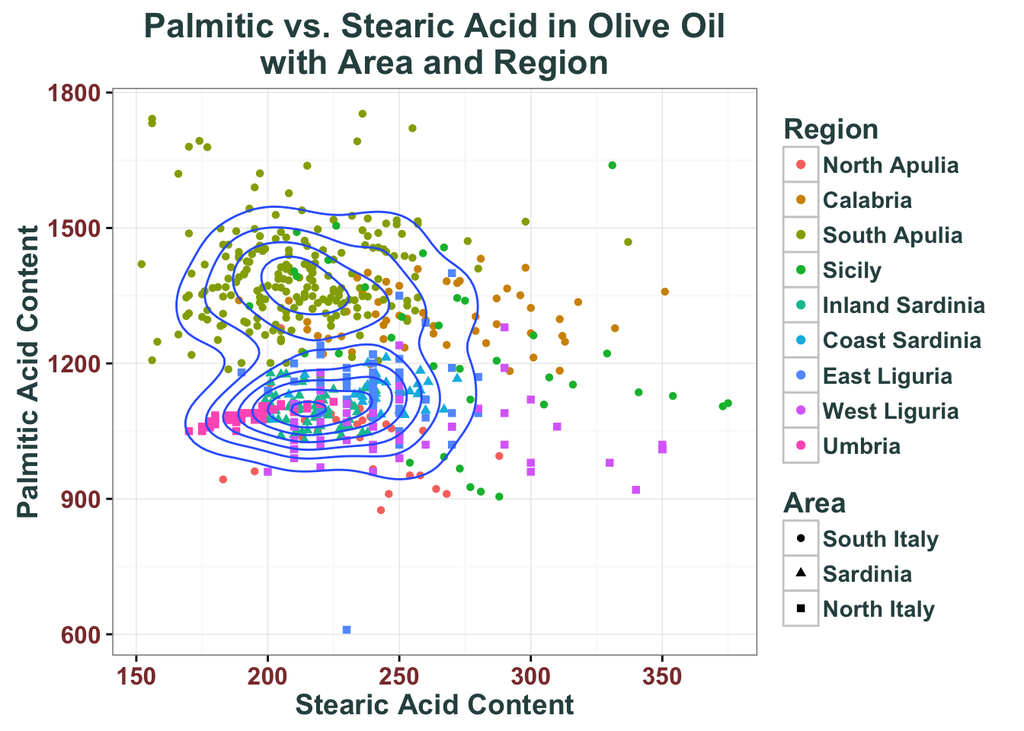

```r
ggplot2::ggplot(data = olive_sub, aes(x = stearic, y = palmitic)) +
  geom_point(aes(col = region, shape = area)) +
  ggtitle("Palmitic vs. Stearic Acid in Olive Oil\nwith Area and Region") +
  labs(x = "Stearic Acid Content", y = "Palmitic Acid Content",
  col = "Region", shape = "Area") +
  guides(color = guide_legend(override.aes = list(linetype = 0))) +
  geom_density2d(aes(x = stearic, y = palmitic)) +
  my_theme
```

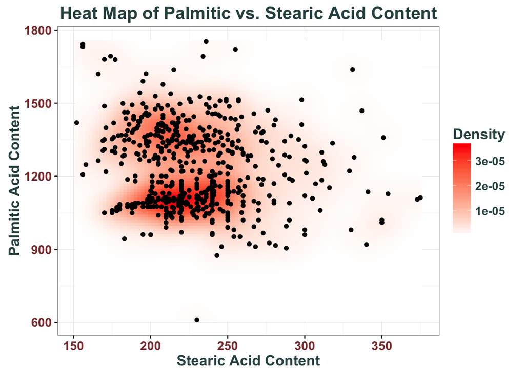

```r
ggplot2::ggplot(data = olive) +
  stat_density2d(aes(x = stearic, y = palmitic, fill = ..density..),
                 geom = "tile", contour = F) +
  geom_point(aes(x = stearic, y = palmitic)) +
  scale_fill_gradient(low = "white", high = "red") +
  ggtitle("Heat Map of Palmitic vs. Stearic Acid Content") +
  labs(x = "Stearic Acid Content", y = "Palmitic Acid Content", fill = "Density") +
  my_theme
```